# Script7_Armbruster2026_RajPandeyOwn_TFcodes

Daniel Armbruster

2026-07-24

- This script produced the z-score heatmap of cluster-specific transcription factors for the CA clusters compared to the whole-brain reference as visualized in Figure 2D as well as the associated data tables presented in Table S2S-AA
- As the whole-brain reference, we use the 5 dpf zebrafish larval whole-brain dataset published by Raj and colleagues deposited as an RDS file on GEO under accession number GSE158142 (Raj et al., 2020; DOI: 10.1016/j.neuron.2020.09.023).
- To identify highly expressed transcription factors in the CA clusters relative to the whole-brain reference, we merged the datasets, normalized the combined data, and computed differentially expressed transcription factors (minimum two fold upregulation, maximum adjusted p-value of 0.05) for each CA cluster (presented in Figure 1E) compared with all whole-brain cells combined into a single reference cluster. Then we visualized the expression of the 50 most highly upregulated transcription factors for each cluster as z-scores.
- The session info including the used packages and their versions is provided at the end of this script.

# 1. Load Packages

```r
library(Seurat)
library(dplyr)
library(openxlsx)
library(ggplot2)
library(readr)
library(tidyverse)
library(cowplot)
library(AnnotationHub)
```

# 2. Load data and merge datasets

## 2.1 Prepare datasets for merging

```r
#### ----- Raj data ----- ####
# Read in the Raj et al. 5 dpf dataset
raj_5d_data <- readRDS("Resources/Raj2020_5dpf/GSE158142_zf5dpf_cc_filt.cluster.rds")

# Update the Seurat object to the current Seurat version
raj_5d_data <- UpdateSeuratObject(raj_5d_data)
```

```
## Updating from v2.X to v3.X
```

```
## Validating object structure
```

```
## Updating object slots
```

```
## Ensuring keys are in the proper structure
```

```
## Updating matrix keys for DimReduc 'pca'
```

```
## Updating matrix keys for DimReduc 'FItSNE'
```

```
## Ensuring keys are in the proper structure
```

```
## Ensuring feature names don't have underscores or pipes
```

```
## Updating slots in RNA
```

```
## Updating slots in pca
```

```
## Updating slots in FItSNE
```

```
## Setting FItSNE DimReduc to global
```

```
## Validating object structure for Assay 'RNA'
```

```
## Validating object structure for DimReduc 'pca'
```

```
## Validating object structure for DimReduc 'FItSNE'
```

```
## Object representation is consistent with the most current Seurat version
```

```r
# Read the feature annotation table containing Ensembl IDs and gene symbols
raj_features <- read.csv(
  "Resources/raj_features.tsv",
  sep = "\t",
  header = FALSE,
  col.names = c("ensembl.id", "gene.symbol")
)

# Rename metadata columns to match the format of the integrated dataset
raj_5d_data@meta.data <- raj_5d_data@meta.data %>% dplyr::rename(orig.cluster = res.1)


#### ----- Integrated (Own+Pandey) data ----- ####
# Read in the integrated data of our own and the Pandey et al. 2023 dataset
integ_own_data <- readRDS("RDS_files/Script6_Armbruster2026_integ_annot.rds")

# Read the feature annotation table containing Ensembl IDs and gene symbols
own_features = read.csv("Resources/own_features.tsv", sep="\t", header = F,col.names = c("ensembl.id", "gene.symbol", "column3"))


# Rename metadata columns to match the format of the integrated dataset
integ_own_data@meta.data <- integ_own_data@meta.data %>% dplyr::rename(pt.mito = MTratio, cell_barcodes = cells, orig.cluster = annotation)


#---------------------------------------------------------------------------------------------------------------------------------------------
#### ----- Extract count matrices and metadata, then convert gene symbols to Ensembl IDs ----- ####
# Both datasets were generated using the same zebrafish reference genome but different Ensembl releases. As gene symbols might differ, we will convert them back to Ensembl IDs prior merging.

#### ----- Raj data ----- ####
# Extract the raw count matrix
raj_counts <- GetAssayData(raj_5d_data,assay = "RNA", slot = "counts")
# Extract meta data
raj_meta <- raj_5d_data@meta.data

# Replace gene symbols with Ensembl IDs
matched_ids_raj <- raj_features$ensembl.id[match(rownames(raj_counts), raj_features$gene.symbol)]
raj_counts <- raj_counts[!is.na(matched_ids_raj), ]
rownames(raj_counts) <- matched_ids_raj[!is.na(matched_ids_raj)]

#### ----- Integrated (Own+Pandey) data ----- ####
# Extract the raw count matrix
integ_own_counts <- GetAssayData(integ_own_data,assay = "RNA", slot = "counts")

# Extract metadata
integ_own_meta <- integ_own_data@meta.data

# Replace gene symbols with Ensembl IDs
matched_ids_integ_own <- own_features$ensembl.id[match(rownames(integ_own_counts), own_features$gene.symbol)]
integ_own_counts <- integ_own_counts[!is.na(matched_ids_integ_own), ]
rownames(integ_own_counts) <- matched_ids_integ_own[!is.na(matched_ids_integ_own)]


# Retain only genes shared between both datasets
common_genes <- intersect(rownames(raj_counts), rownames(integ_own_counts))
raj_counts <- raj_counts[common_genes, , drop = FALSE]
integ_own_counts <- integ_own_counts[common_genes, , drop = FALSE]
integ_own_counts <- integ_own_counts[rownames(raj_counts), , drop = FALSE]

# Verify that both matrices have identical gene order
identical(rownames(raj_counts), rownames(integ_own_counts))
```

```
## [1] TRUE
```

```r
# Create new Seurat objects from the harmonized count matrices and metadata
integ_own_seurat <- CreateSeuratObject(counts = integ_own_counts, meta.data = integ_own_meta, project = "integ_own_data")
raj_seurat <- CreateSeuratObject(counts = raj_counts, meta.data = raj_meta, project = "raj_data")
```

## 2.2 Merge datasets and restore gene symbols

```r
# Merge datasets
merged_seurat <- merge(
  raj_seurat,
  y = integ_own_seurat,
  add.cell.ids = c("raj", "pand+own"),
  project = "5dpf_merged"
)

#Create a mapping table to convert Ensembl IDs back to gene symbols
ensembl_to_own <- setNames(own_features$gene.symbol,
                           own_features$ensembl.id)

# Map Ensembl IDs from the merged Seurat object back to gene symbols
mapped_symbols <- unname(ensembl_to_own[rownames(merged_seurat)])

# Check whether unmapped Ensembl IDs were generated
sum(is.na(mapped_symbols))
```

```
## [1] 0
```

```r
# Check whether mapping resulted in duplicated gene symbols
dup_symbols <- mapped_symbols[duplicated(mapped_symbols)]
length(unique(dup_symbols))
```

```
## [1] 0
```

```r
# No unmapped IDs or duplicated gene symbols were generated

# Replace Ensembl IDs with gene symbols as row names
rownames(merged_seurat) <- mapped_symbols
```

```r
# Remove objects to reduce memory usage
rm(integ_own_data, integ_own_meta, integ_own_seurat, raj_5d_data, raj_counts, raj_seurat)
gc()
```

```
##            used  (Mb) gc trigger    (Mb)   max used    (Mb)
## Ncells  6509540 347.7   11888250   635.0   11888250   635.0
## Vcells 56139269 428.4 2291610280 17483.6 2709828623 20674.4
```

# 4. Identify differentially expressed transcription factors

## 4.1 Normalize and prepare cluster identities

```r
# Set original cluster annotations as identities for downstream differential expression analysis
Idents(object = merged_seurat) <- "orig.cluster"

# Normalize the merged dataset using SCTransform
merged_seurat <- SCTransform(merged_seurat)
```

```
## Running SCTransform on assay: RNA
```

```
## vst.flavor='v2' set. Using model with fixed slope and excluding poisson genes.
```

```
## Calculating cell attributes from input UMI matrix: log_umi
```

```
## Variance stabilizing transformation of count matrix of size 18214 by 31659
```

```
## Model formula is y ~ log_umi
```

```
## Get Negative Binomial regression parameters per gene
```

```
## Using 2000 genes, 5000 cells
```

```
## Found 588 outliers - those will be ignored in fitting/regularization step
```

```
## Second step: Get residuals using fitted parameters for 18214 genes
```

```
## Computing corrected count matrix for 18214 genes
```

```
## Wall clock passed: Time difference of 2.695764 mins
```

```
## Determine variable features
```

```
## Centering data matrix
```

```
## Place corrected count matrix in counts slot
```

```
## vst.flavor='v2' set. Using model with fixed slope and excluding poisson genes.
```

```
## Calculating cell attributes from input UMI matrix: log_umi
```

```
## Variance stabilizing transformation of count matrix of size 9757 by 340
```

```
## Model formula is y ~ log_umi
```

```
## Get Negative Binomial regression parameters per gene
```

```
## Using 2000 genes, 340 cells
```

```
## Found 100 outliers - those will be ignored in fitting/regularization step
```

```
## Second step: Get residuals using fitted parameters for 9757 genes
```

```
## Computing corrected count matrix for 9757 genes
```

```
## Wall clock passed: Time difference of 5.337759 secs
```

```
## Determine variable features
```

```
## Centering data matrix
```

```
## Place corrected count matrix in counts slot
```

```
## Set default assay to SCT
```

```r
# Prepare the SCT assay for differential expression testing
merged_seurat <- PrepSCTFindMarkers(merged_seurat, assay = "SCT")
```

```
## Found 2 SCT models. Recorrecting SCT counts using minimum median counts: 1681
```

```r
# Combine Raj whole-brain clusters into a single whole-brain reference cluster (WB)
# (other clusters correspond to the CA clusters and retain their original label)
merged_seurat <- RenameIdents(merged_seurat, "0" = "WB", "1" = "WB", "2" = "WB", "3" = "WB", "4" = "WB", "5" = "WB", "6" = "WB", "7" = "WB", "8" = "WB", "9" = "WB", "10" = "WB", "11" = "WB", "12" = "WB", "13" = "WB", "14" = "WB", "15" = "WB", "16" = "WB", "17" = "WB", "18" = "WB", "19" = "WB", "20" = "WB", "21" = "WB", "22" = "WB", "23" = "WB", "24" = "WB", "25" = "WB", "26" = "WB", "27" = "WB", "28" = "WB", "29" = "WB", "30" = "WB", "31" = "WB", "32" = "WB", "33" = "WB", "34" = "WB", "35" = "WB", "36" = "WB", "37" = "WB", "38" = "WB", "39" = "WB", "40" = "WB", "41" = "WB", "42" = "WB", "43" = "WB", "44" = "WB", "45" = "WB", "46" = "WB", "47" = "WB", "48" = "WB", "49" = "WB", "50" = "WB", "51" = "WB", "52" = "WB")

merged_seurat$DEG_sample_names <- Idents(merged_seurat)
```

## 4.1 Perform differential expression analysis of each CA cluster against the whole-brain reference

```r
# Define clusters to analyse in the DEG loop
clusters_for_DEG <- levels(merged_seurat$DEG_sample_names)


# Load zebrafish transcription factor annotation list used to extract transcription factors from DEG results ( List from Animal Transcription Factor Database 3.0 (AnimalTFDB3.9))
TFlist <- read_tsv(file = "Resources/DanioRerio_TF.tsv")
# Rename gene symbol column and remove unnecessary annotation columns
names(TFlist)[names(TFlist) == "Symbol"] <- "gene"
TFlist$Species <- NULL
TFlist$Ensembl <- NULL
TFlist$Family <- NULL
TFlist$Protein <- NULL
TFlist$`Entrez ID` <- NULL

# Remove duplicated transcription factor entries
TFlist <- TFlist[!duplicated(TFlist$gene),]

# Define output directory for DEG tables
savepath <- "DEG_tables/Script7_RajPandeyOwn_TFs/"

# Initialize lists for the storage of DEG results and transcription factor subsets
tf_top50_list <- list()
all_markers_list <- list()
tf_markers_list <- list()

# Perform the differential expression analysis on the SCT data slot of each CA cluster against whole-brain reference
for (cluster in clusters_for_DEG) {

  print(paste("Current cluster:", cluster))
  markers_wb_vs_CA <- FindMarkers(
    merged_seurat,
    ident.1 = cluster,
    ident.2 = "WB",
    min.pct = 0.2,
    logfc.threshold = 1,
    only.pos = T
  )

  # Add gene names and cluster identity to the DEG table
  markers_wb_vs_CA$gene <- row.names(markers_wb_vs_CA)
  try(markers_wb_vs_CA$cluster <- cluster)

  # Retain significantly enriched genes and rank them by average log2 fold change
  try(markers_wb_vs_CA <- markers_wb_vs_CA %>%
    dplyr::filter(p_val_adj <= 0.05)
      %>% dplyr::arrange(desc(avg_log2FC)))

   # Extract transcription factors from the DEG list and store the top 50 TFs ranked by average log2 fold change
  markers_wb_vs_CA_TFs <- inner_join(markers_wb_vs_CA, TFlist, by = "gene")
  top_TF_genes_up <- markers_wb_vs_CA_TFs %>% dplyr::arrange(desc(avg_log2FC))
  tf_top50_list[[cluster]] <- top_TF_genes_up$gene[1:50]

  # Store all DEGs and transcription factor DEGs
  all_markers_list[[cluster]] <- markers_wb_vs_CA
  tf_markers_list[[cluster]] <- markers_wb_vs_CA_TFs


}
```

```
## [1] "Current cluster: WB"
```

[output not shown]

[output not shown]

```
## [1] "Current cluster: OB"
## [1] "Current cluster: Hyp"
## [1] "Current cluster: EMeA"
## [1] "Current cluster: vFb"
## [1] "Current cluster: PoA"
## [1] "Current cluster: PoA-PTh"
```

```r
# Export top 50 transcription factors per cluster
write.csv(tf_top50_list, file= paste(savepath, "tf_genes_sorted_lists/Script4_RajOwnPandey_DEG_tfgenelist_Top50.csv", sep = ""))


# Rename list entries to show the comparison performed
names(all_markers_list) <- paste0(names(all_markers_list), "_vs_WB_allgenes")
names(tf_markers_list) <- paste0(names(tf_markers_list), "_vs_WB_TFgenes")

# Combine and export the DEG tables
combined_list <- c(all_markers_list, tf_markers_list)
combined_list <- combined_list[order(names(combined_list))]
write.xlsx(combined_list, file = paste0(savepath, "Script7_RajPandeyOwnMerge_cluster_vs_WB_DEGs.xlsx"))
```

```r
# Load the saved top 50 transcription factors for all clusters and make them unique
tf_all_clusters_50 <- read.csv(paste(savepath, "tf_genes_sorted_lists/Script4_RajOwnPandey_DEG_tfgenelist_Top50.csv", sep = ""))[-1]
all_TFs <- unique(unlist(tf_all_clusters_50))

# Calculate average SCT-normalized expression of the transcription factors per cluster
avg <- AverageExpression(
  merged_seurat,
  features = all_TFs,
  group.by = "ident",
  assays = DefaultAssay(merged_seurat),
  slot = "data"
)
```

```
## As of Seurat v5, we recommend using AggregateExpression to perform pseudo-bulk analysis.
```

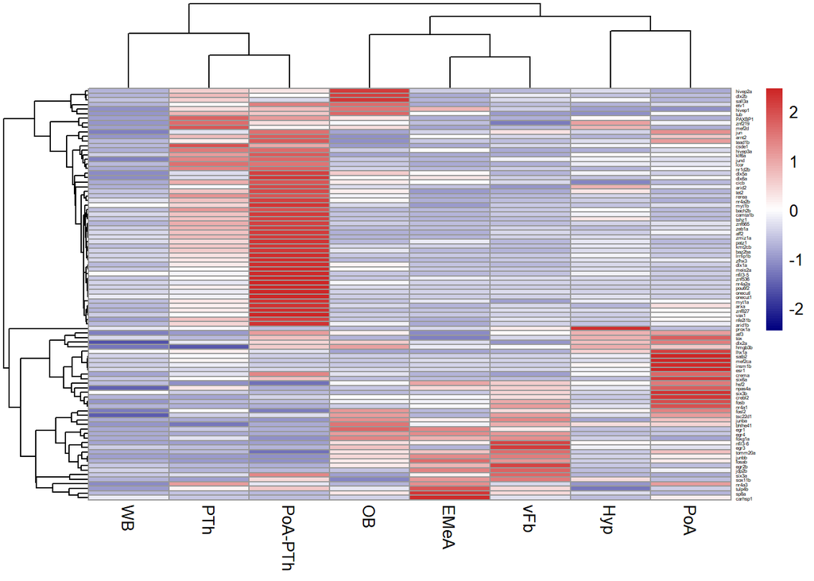

```r
# Scale TF expression values across clusters for visualization
avg_mat <- avg[[DefaultAssay(merged_seurat)]]
avg_scaled <- t(scale(t(avg_mat)))
avg_scaled[is.na(avg_scaled)] <- 0
lim <- max(abs(avg_scaled))
breaks <- seq(-lim, lim, length.out = 101)

# Generate the heatmap of transcription factor expression patterns across clusters as z-score
DEG_heatmap <- pheatmap::pheatmap(avg_scaled,
  cluster_rows = TRUE,
  cluster_cols = TRUE,
  clustering_distance_rows = "correlation",
  clustering_distance_cols = "correlation",
  clustering_method = "average",
  color = colorRampPalette(c("navy","white","firebrick3"))(100),
  breaks = breaks,
  silent = TRUE,
  width = 10,
  height = 10,
  fontsize_row = 3
)

# Save heatmap as SVG file
print(DEG_heatmap)
```

```r
svg(paste(savepath, "Script6_Figure2_RajOwnPandey_TF_heatmap_Top50.svg", sep = ""), width = 10, height = 10)
grid::grid.draw(DEG_heatmap$gtable)
dev.off()
```

```r
# Prepare associated data for export
avg_mat <- as.data.frame(avg_mat)
avg_mat <- avg_mat[, order(names(avg_mat), decreasing=F)]
avg_mat <- avg_mat %>% dplyr::select("WB", everything())
avg_scaled <- as.data.frame(avg_scaled)
avg_scaled <- avg_scaled[, order(names(avg_scaled), decreasing=F)]
avg_scaled <- avg_scaled %>% dplyr::select("WB", everything())
dataframe_names <- list("avg_SCT_expression" = avg_mat, "scaled_avg_SCT_values" = avg_scaled)

# Export average SCT-normalized expression values and z-score transformed values used to generate the heatmap
openxlsx::write.xlsx(dataframe_names, file = paste(savepath, "Script7_RajPandeyOwn_HeatmapTable.xlsx", sep = ""), rowNames=T)
```

```r
# Identify the 3 transcription factors with the highest z-score per clusters to label them in the heatmap.
label_genes <- lapply(colnames(avg_scaled), function(cl){

  genes <- rownames(avg_scaled)[
    apply(avg_scaled, 1, which.max) == which(colnames(avg_scaled)==cl)
  ]

  zvals <- avg_scaled[genes, cl]

  head(genes[order(zvals, decreasing=TRUE)], 3)

})
label_genes <- unique(unlist(label_genes))
label_genes
```

```
##  [1] "carhsp1" "sp8a"    "tulp4b"  "prox1a"  "sall3a"  "hivep2a" "dlx2b"
##  [8] "esr1"    "satb2"   "mef2ca"  "onecutl" "nr4a2a"  "onecut1" "csde1"
## [15] "mef2d"   "PAXBP1"  "egr3"    "nfil3-6" "egr2b"
```

```r
# Remove objects to reduce memory usage
rm(list=ls())
gc()
```

```
##            used  (Mb) gc trigger    (Mb)   max used    (Mb)
## Ncells  9429720 503.7   17774944   949.3   17774944   949.3
## Vcells 16827706 128.4 1760007896 13427.8 2743334144 20930.0
```